# UDACITY R Data Analysis Lesson 4

#### Histogram of Price/Carat of diamonds with a Log10 x scale and Facet_wrap for cut

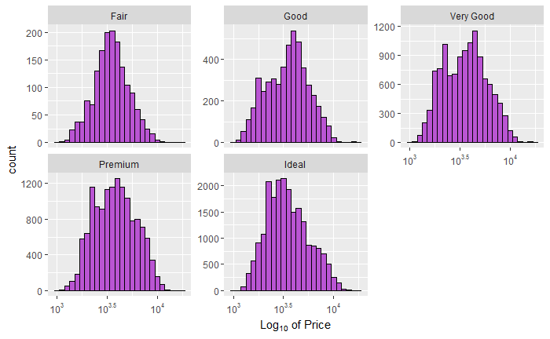

```r
p_hist = ggplot(aes(x = price/carat), data = diamonds) +
  geom_histogram(binwidth = 0.05, color = 'black', fill = '#BA55D3') +
  scale_x_log10(expression(paste(Log[10], " of Price")),
                breaks = trans_breaks("log10", function(x) 10^x),
                labels = trans_format("log10", math_format(10^.x))) +
  facet_wrap(~cut, scales="free_y")
p_hist
```

#### Original Histogram of Price

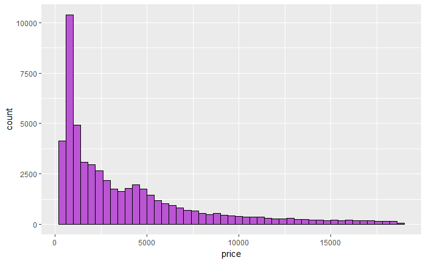

```r
ggplot(aes(x = price), data = diamonds) +
  geom_histogram(binwidth = 400, color = 'black', fill = '#BA55D3')
```

#### Histogram of Price/Carat

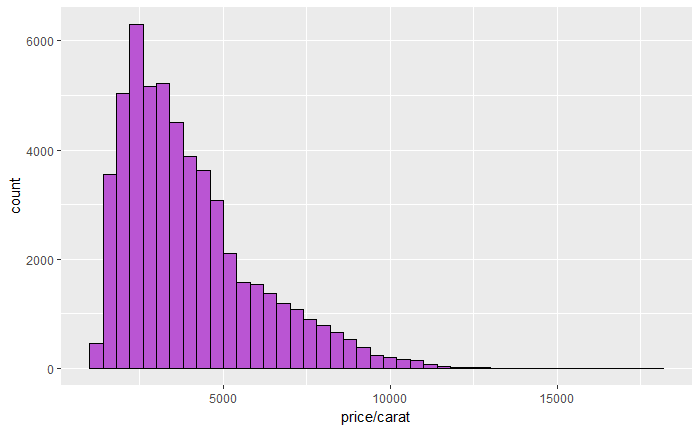

```r
ggplot(aes(x = price/carat), data = diamonds) +
  geom_histogram(binwidth = 400, color = 'black', fill = '#BA55D3')
```

### Lesson 4.10: Quiz: Price Box Plots

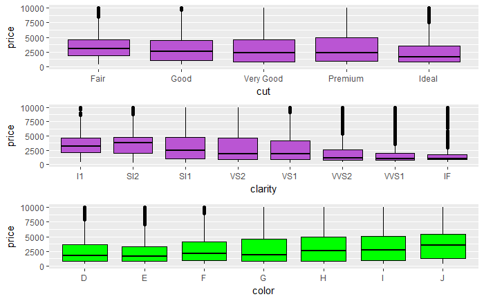

```r
p_cut = ggplot(diamonds, aes(x = cut, y = price)) +
  geom_boxplot(fill = '#BA55D3', color = 'black') +
  scale_y_continuous(limits = c(0, 10000))
p_clarity = ggplot(diamonds, aes(x = clarity, y = price)) +
  geom_boxplot(fill = '#BA55D3', color = 'black') +
  scale_y_continuous(limits = c(0, 10000))
p_color = ggplot(diamonds, aes(x = color, y = price)) +
  geom_boxplot(fill = 'green', color = 'black') +
  scale_y_continuous(limits = c(0, 10000))
grid.arrange(p_cut, p_clarity, p_color, ncol = 1)
```

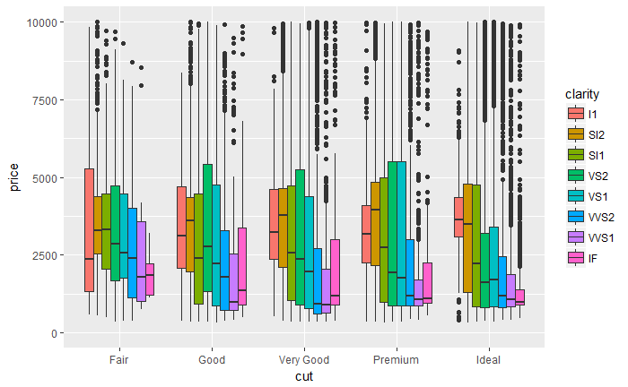

```r
ggplot(diamonds, aes(x = cut, y = price)) +
  geom_boxplot(aes(fill = clarity)) +
  scale_y_continuous(limits = c(0, 10000))
```

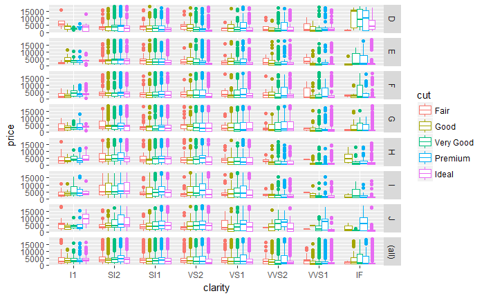

```r
ggplot(diamonds, aes(x = clarity, y = price, color = cut)) +
  geom_boxplot() +
  facet_grid(color~., margins = TRUE)
```

### Lesson 4.11: Quiz: Interquartile Range - IQR

```r
IQR(subset(diamonds, color=='J')$price)
```

```
[1] 5834.5
```

```r
IQR(subset(diamonds, color=='D')$price)
```

```
[1] 3302.5
```

```r
diamonds %>%
  group_by(color) %>%
  filter(color == "D") %>%
  summarise(Quartile_1st = quantile(price, 0.25),
            Quartile_3rd = quantile(price, 0.75),
            IQR = Quartile_3rd - Quartile_1st)
```

| color | Quartile_1st | Quartile_3rd | IQR |
| --- | --- | --- | --- |
| D | 911 | 4213.5 | 3302.5 |

```r
diamonds %>%
  group_by(color) %>%
  filter(color == "J") %>%
  summarise(Quartile.25 = quantile(price, 0.25),
            Quartile.75 = quantile(price, 0.75),
            IQR = Quartile.75 - Quartile.25)
```

| color | Quartile.25 | Quartile.75 | IQR |
| --- | --- | --- | --- |
| J | 1860.5 | 7695 | 5834.5 |

### Lesson 4.12: Quiz: Price/Carat Box Plots by Color

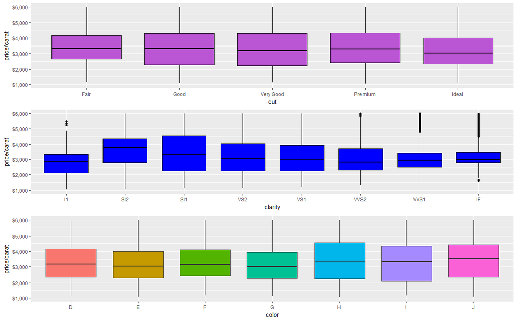

```r
p_cut = ggplot(diamonds, aes(x = cut, y = price/carat)) +
  geom_boxplot(fill = '#BA55D3', color = 'black') +
  scale_y_continuous(limits = c(1000, 6000), breaks = seq(1000, 6000, 1000), labels=dollar)
p_clarity = ggplot(diamonds, aes(x = clarity, y = price/carat)) +
  geom_boxplot(fill = 'blue', color = 'black') +
  scale_y_continuous(limits = c(1000, 6000), breaks = seq(1000, 6000, 1000), labels=dollar)
p_color = ggplot(diamonds, aes(x = color, y = price/carat)) +
  geom_boxplot(aes(fill = color)) +
  scale_y_continuous(limits = c(1000, 6000), breaks = seq(1000, 6000, 1000), labels=dollar) +
  theme(legend.position = 'none')
grid.arrange(p_cut, p_clarity, p_color, ncol = 1)
```

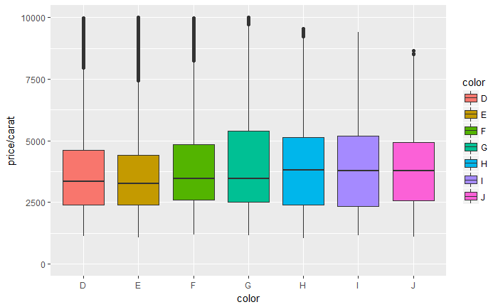

```r
ggplot(diamonds, aes(x = color, y = price/carat)) +
  geom_boxplot(aes(fill=color)) +
  scale_y_continuous(limits = c(0, 10000))
```

### Lesson 4.13: Quiz: Carat Frequency Polygon

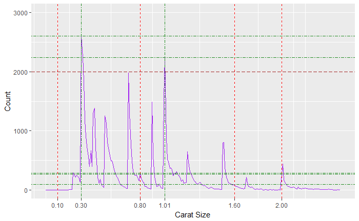

```r
ggplot(data = diamonds, aes(x=carat)) +
  geom_freqpoly(binwidth = .01, color = 'purple') +
  scale_x_continuous(limits = c(0, 2.5), breaks = c(0.1, 0.3, 0.8, 1.01, 1.6, 2.0, 3.0, 5.0)) +
  scale_y_continuous(limits = c(0, 3000)) +
  geom_vline(xintercept = c(0.1, 0.8, 1.6, 2.0, 3.0, 5.0), color = "red", linetype="dashed") +
  geom_vline(xintercept = c(0.3, 1.01), color = "forestgreen", linetype = "twodash") +
  geom_hline(yintercept = 2000, color = "brown", linetype="longdash") +
  geom_hline(yintercept = c(2604, 284, 2242, 95, 265), color = "forestgreen", linetype="twodash") +
  xlab("Carat Size") + ylab("Count")
```

```r
values = c(0.1, 0.3, 0.8, 1.01, 1.6, 2.0, 3.0, 5.0)
for (i in values) {
  print(table(diamonds$carat == i))
}
```

```
FALSE
53940

FALSE  TRUE
51336  2604

FALSE  TRUE
53656   284

FALSE  TRUE
51698  2242

FALSE  TRUE
53845    95

FALSE  TRUE
53675   265

FALSE  TRUE
53932     8

FALSE
53940
```

### Lesson 4.15: Gapminder Data

The Gapminder website contains over 500 data sets with information about the world’s population. Your task is to download a data set of your choice and create 2-5 plots that make use of the techniques from Lesson 3.

You might use a simple histogram, a boxplot split over a categorical variable, or a frequency polygon. The choice is yours!

You can find a link to the Gapminder website in the Instructor Notes.

Once you’ve completed your investigation, create a post in the discussions that includes:

1. any questions you answered, your observations, and summary statistics
2. snippets of code that created the plots
3. links to the images of your plots

http://www.gapminder.org/data/ (hours per week) -> Working hours per week

```r
working_hours = read_excel('working_hours_per_week.xlsx', sheet='Data')
```

```r
headers = colnames(working_hours)
headers
```

```
 [1] "Working hours per week" "1980.0"                 "1981.0"                 "1982.0"                 "1983.0"
 [6] "1984.0"                 "1985.0"                 "1986.0"                 "1987.0"                 "1988.0"
[11] "1989.0"                 "1990.0"                 "1991.0"                 "1992.0"                 "1993.0"
[16] "1994.0"                 "1995.0"                 "1996.0"                 "1997.0"                 "1998.0"
[21] "1999.0"                 "2000.0"                 "2001.0"                 "2002.0"                 "2003.0"
[26] "2004.0"                 "2005.0"                 "2006.0"                 "2007.0"
```

```r
rownames(working_hours)
```

```
 [1] "1"  "2"  "3"  "4"  "5"  "6"  "7"  "8"  "9"  "10" "11" "12" "13" "14" "15" "16" "17" "18" "19" "20" "21" "22" "23" "24" "25" "26"
[27] "27" "28" "29" "30" "31" "32" "33" "34" "35" "36" "37" "38" "39" "40" "41" "42" "43" "44" "45" "46" "47" "48" "49" "50" "51" "52"
```

```r
names(working_hours)[names(working_hours) == "Working hours per week"] = 'Country'
```

```r
for (i in headers) {
  if (i != 'Country'){
    names(working_hours)[names(working_hours) == i] = substr(i, 1, 4)
  }
}
```

```r
# Flatten the table
hours_flat = melt(working_hours, id=c("Country"), value.name="Hours", variable.name="Year", na.rm = TRUE)
```

```r
# Convert Year and Hours to numeric and round Hours to integer
hours_flat <- hours_flat %>%
  mutate(Year = as.numeric(as.character(Year)),
         Hours = as.numeric(Hours),
         Hours = round(Hours, 2))
```

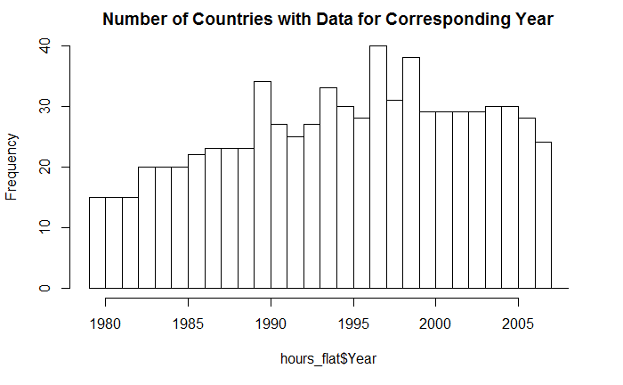

```r
hist(hours_flat$Year, breaks=seq(1979, 2008, by=1), main='Number of Countries with Data for Corresponding Year')
```

Resources:

1. http://www.cookbook-r.com/Graphs/Plotting_distributions_(ggplot2)/
2. https://www.statmethods.net/graphs/density.html
3. https://www.r-bloggers.com/basics-of-histograms/

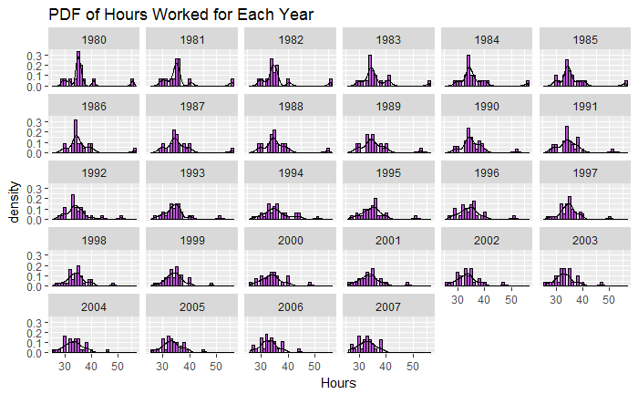

```r
ggplot(aes(x = Hours), data = hours_flat) +
  geom_histogram(binwidth = 1, aes(y=..density..), color = 'black', fill = '#BA55D3') +
  geom_density(aes(y=..density..)) +
  facet_wrap(~Year) + # or add: scales="free"
  ggtitle('PDF of Hours Worked for Each Year')
```

```r
yearStats <- hours_flat %>%
  group_by(Year) %>%
  summarise(mean = mean(Hours),
            median = median(Hours),
            std_dev = sd(Hours),
            min = min(Hours),
            max = max(Hours),
            quartile_1st = quantile(Hours, 0.25),
            quartile_3rd = quantile(Hours, 0.75),
            IQR = quartile_3rd - quartile_1st,
            std_error = std_dev/sqrt(length(Hours)),
            countries_with_data = length(Hours))
yearStats
```

| Year | mean | median | std_dev | min | max | quartile_1st | quartile_3rd | IQR | std_error | countries_with_data |
| --- | --- | --- | --- | --- | --- | --- | --- | --- | --- | --- |
| 1980 | 35.99600 | 34.850 | 5.989155 | 29.17 | 55.31 | 34.3350 | 35.8000 | 1.4650 | 1.5463933 | 15 |
| 1981 | 35.73067 | 34.630 | 6.137977 | 29.01 | 55.62 | 33.6600 | 35.7900 | 2.1300 | 1.5848189 | 15 |
| 1982 | 35.63933 | 34.380 | 6.196078 | 29.28 | 55.87 | 33.6100 | 35.7450 | 2.1350 | 1.5998204 | 15 |
| 1983 | 36.06650 | 34.565 | 5.703803 | 29.46 | 56.21 | 33.8325 | 36.5775 | 2.7450 | 1.2754092 | 20 |
| 1984 | 35.88700 | 34.450 | 5.597352 | 29.50 | 56.13 | 33.5550 | 36.3450 | 2.7900 | 1.2516059 | 20 |
| 1985 | 35.84950 | 34.470 | 5.512410 | 29.58 | 55.65 | 33.8025 | 36.3325 | 2.5300 | 1.2326124 | 20 |
| 1986 | 35.85591 | 34.475 | 5.377738 | 29.54 | 56.21 | 33.8500 | 37.0200 | 3.1700 | 1.1465375 | 22 |
| 1987 | 35.52435 | 34.580 | 5.358130 | 29.05 | 55.62 | 33.4600 | 37.0050 | 3.5450 | 1.1172474 | 23 |
| 1988 | 35.51348 | 34.740 | 5.213261 | 29.02 | 54.73 | 33.4050 | 37.0200 | 3.6150 | 1.0870400 | 23 |
| 1989 | 35.30957 | 34.660 | 4.942761 | 28.79 | 52.73 | 33.1600 | 37.0500 | 3.8900 | 1.0306369 | 23 |

[output cut: 18 more lines]

```r
years_by_country = hours_flat %>%
  group_by(Country) %>%
  summarise(number_of_years = length(Year))
```

```r
filter(years_by_country, number_of_years == 28)
```

| Country | number_of_years |
| --- | --- |
| Australia | 28 |
| Canada | 28 |
| Finland | 28 |
| France | 28 |
| Iceland | 28 |
| Italy | 28 |
| Japan | 28 |
| Norway | 28 |
| Spain | 28 |
| Sweden | 28 |

[output cut: 2 more lines]

Resources:

1. http://www.sthda.com/english/wiki/ggplot2-axis-ticks-a-guide-to-customize-tick-marks-and-labels
2. http://www.sthda.com/english/wiki/ggplot2-themes-and-background-colors-the-3-elements
3. http://www.cookbook-r.com/Graphs/
4. http://www.cookbook-r.com/Graphs/Colors_(ggplot2)/
5. http://www.cookbook-r.com/Graphs/Axes_(ggplot2)/

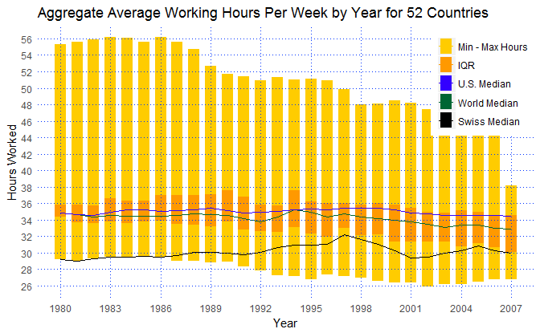

```r
p = ggplot(yearStats, aes(x=Year, y=median))  +
  theme(panel.background = element_rect(fill='#ffffff'),
        plot.background = element_blank(),
        panel.grid.minor = element_blank(),
        panel.grid.major = element_blank(),
        panel.border = element_blank(),
        axis.ticks = element_blank(),
        legend.title=element_blank(),
        legend.justification=c(1,1), legend.position=c(1,1)) +

  ylab('Hours Worked') +
  ggtitle('Aggregate Average Working Hours Per Week by Year for 52 Countries') +

  geom_linerange(yearStats, mapping=aes(x=Year, ymin=min, ymax=max, color = 'Min - Max Hours'), size=5) +
  geom_linerange(yearStats, mapping=aes(x=Year, ymin=quartile_1st, ymax=quartile_3rd, color = 'IQR'), size=5) +
  geom_line(yearStats, mapping=aes(x=Year, y=median, group=1, color= 'World Median'))  +
  geom_line(data = subset(hours_flat, Country == "United States"),
            aes(x = Year, y = Hours, group = Country, color = 'U.S. Median')) +
  geom_line(data = subset(hours_flat, Country == 'Sweden'),
            aes(x = Year, y = Hours, group = Country, color = 'Swiss Median')) +

  scale_color_manual(values = c('Min - Max Hours' = '#FFCC00', 'IQR' = '#FF9900',
                                'World Median' = '#006633', 'U.S. Median' = '#3300FF', 'Swiss Median' = '#000000'),
                     breaks = c('Min - Max Hours', 'IQR', 'U.S. Median', 'World Median', 'Swiss Median')) +


  geom_hline(yintercept=seq(26, 56, 2), color='#0033FF', linetype=3) +
  geom_vline(xintercept = seq(1980, 2007, 3), color='#0033FF', linetype=3, size=0.5) +
  coord_cartesian(ylim = c(26,56)) +
  scale_y_continuous(breaks=seq(26, 56, 2)) +
  scale_x_continuous(breaks=seq(1980, 2007, 3))
p
```

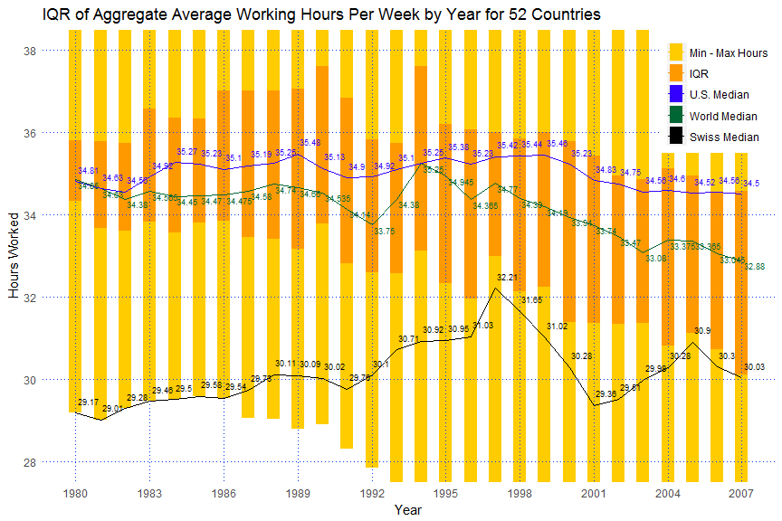

```r
p + coord_cartesian(ylim=c(28, 38)) +
  ggtitle('IQR of Aggregate Average Working Hours Per Week by Year for 52 Countries') +
  geom_text(data = hours_flat[hours_flat$Country == "United States",],
            aes( x = Year, y = Hours, color = Country, group = Country, label = Hours),
            hjust = -.1, vjust = -1.2, size = 2.5, color = '#3300FF') +
  geom_text(data = hours_flat[hours_flat$Country == "Sweden",],
            aes( x = Year, y = Hours, color = Country, group = Country, label = Hours),
            hjust = -.1, vjust = -1.2, size = 2.5, color = '#000000') +
  geom_text( aes(x = Year, y = median, label = median), hjust = -.1, vjust = 1.2, size = 2.5, color = '#006633')
```

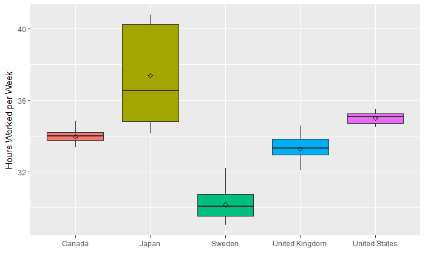

```r
ggplot(subset(hours_flat, Country %in% c("Sweden", "United States", "Japan", "United Kingdom", "Canada")),
       aes(x=Country, y=Hours, fill=Country)) +
  geom_boxplot() +
  stat_summary(fun.y = mean, geom="point", shape = 5) +
  ylab("Hours Worked per Week") + xlab("") +
  theme(legend.position="none")
```

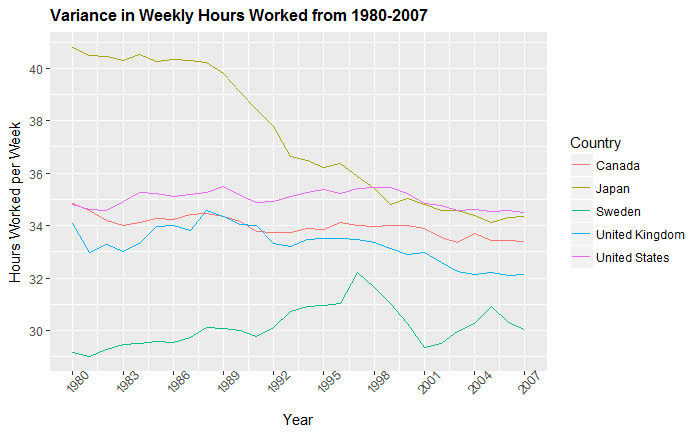

```r
ggplot(subset(hours_flat, Country %in% c("Sweden", "United States", "Japan", "United Kingdom", "Canada")),
       aes(x = Year, y = Hours)) +
  geom_line(aes(color = Country, group = Country)) +
  theme(axis.text.x = element_text(angle = 45)) +
  scale_y_continuous(breaks=seq(26, 56, 2)) +
  scale_x_continuous(breaks=seq(1980, 2007, 3)) +
  ylab('Hours Worked per Week') + xlab('Year') +
  theme(plot.title=element_text(face="bold", size=12)) +
  ggtitle("Variance in Weekly Hours Worked from 1980-2007")
```

### Lesson 4.16: Quiz: Exploring Your Friends’ Birthdays

Your task is to investigate the distribution of your friends’ birth months and days.

Here some questions you could answer, and we hope you think of others.

1. How many people share your birthday? Do you know them? (Reserve time with them or save money to buy them a gift!)
2. Which month contains the most number of birthdays?
3. How many birthdays are in each month?
4. Which day of the year has the most number of birthdays?
5. Do you have at least 365 friends that have birthdays on everyday of the year?

You will need to do some data munging and additional research to complete this task. This task won’t be easy, and you may encounter some unexpected challenges along the way. We hope you learn a lot from it though.

You can expect to spend 30 min or more on this task depending if you use the provided data or obtain your personal data. We also encourage you to use the lubridate package for working with dates. Read over the documentation in RStudio and search for examples online if you need help.

You’ll need to export your Facebooks friends’ birthdays to a csv file. You may need to create a calendar of your Facebook friends’ birthdays in a program like Outlook or Gmail and then export the calendar as a csv file.

Once you load the data into R Studio, you can use the strptime() function to extract the birth months and birth days. We recommend looking up the documentation for the function and finding examples online.

```r
bds <- read.csv("birthdaysExample.csv")
```

```r
dates_ymd <- mdy(bds$dates)
```

```r
bds <- bds %>%
  mutate(Birthday = dates_ymd,
         Year = year(dates_ymd),
         Month = month(dates_ymd, label = TRUE),
         Day = day(dates_ymd),
         Weekday = weekdays(dates_ymd))
```

```r
bds$Weekday <- factor(bds$Weekday, levels=c('Monday', 'Tuesday','Wednesday','Thursday','Friday','Saturday','Sunday'), ordered=TRUE)
```

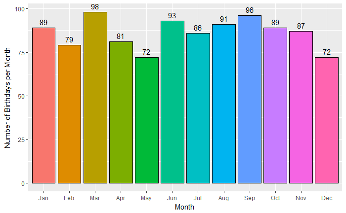

```r
ggplot(bds, aes(x = Month, fill = Month)) +
  geom_bar(color = "Black", show.legend = FALSE) +
  geom_text(stat = "count", aes(label = ..count..), vjust = -0.5) +
  ylab("Number of Birthdays per Month")
```

```r
t = table(bds$Month)
t
```

```
Jan Feb Mar Apr May Jun Jul Aug Sep Oct Nov Dec
 89  79  98  81  72  93  86  91  96  89  87  72
```

```r
bds %>%
  group_by(Month) %>%
  summarise(n = n())
```

| Month | n |
| --- | --- |
| Jan | 89 |
| Feb | 79 |
| Mar | 98 |
| Apr | 81 |
| May | 72 |
| Jun | 93 |
| Jul | 86 |
| Aug | 91 |
| Sep | 96 |
| Oct | 89 |

[output cut: 2 more lines]

```r
names(t)[which.max(t)]
```

```
[1] "Mar"
```

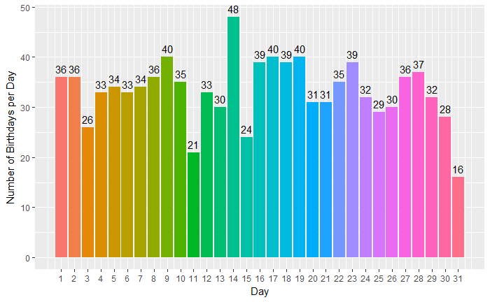

```r
ggplot(bds, aes(x = Day, fill = factor(Day))) +
  geom_bar(show.legend = FALSE) +
  geom_text(stat = "count", aes(label = ..count..), vjust = -0.5) +
  scale_x_continuous(breaks = seq(1, 31, 1)) +
  ylab("Number of Birthdays per Day")
```

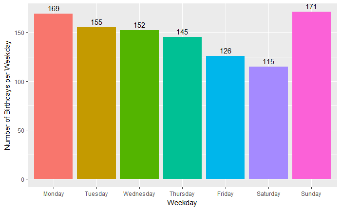

```r
ggplot(bds, aes(x = Weekday, fill = Weekday)) +
  geom_bar(show.legend = FALSE) +
  geom_text(stat = "count", aes(label = ..count..), vjust = -0.5) +
  ylab("Number of Birthdays per Weekday")
```

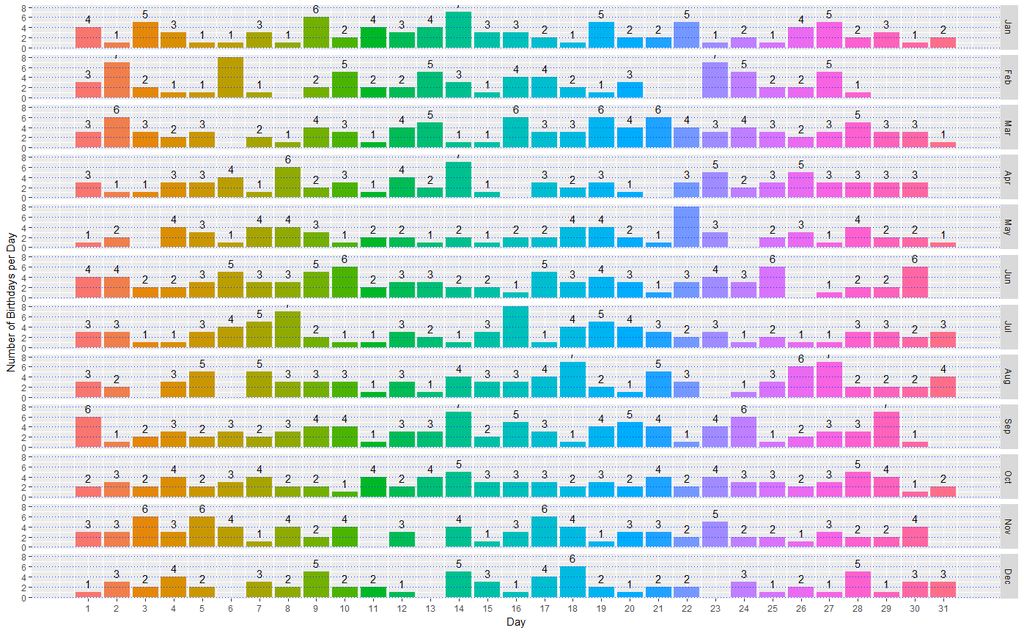

```r
ggplot(bds, aes(x = Day, fill = factor(Day))) +
  geom_bar(show.legend = FALSE) +
  geom_text(stat = "count", aes(label = ..count..), vjust = -0.5) +
  scale_x_continuous(breaks = seq(1, 31, 1)) +
  ylab("Number of Birthdays per Day") +
  facet_grid(Month ~ .) +
  geom_hline(yintercept=seq(0, 8, 2), color='#0033FF', linetype=3)
```

Resources:

1. http://mgimond.github.io/ES218/Week03a.html
2. http://ggplot2.tidyverse.org/reference/facet_grid.html

```r
subset(bds, (Month == "Aug") & (Day == 21))
```

|  | dates | Birthday | Year | Month | Day | Weekday |
| --- | --- | --- | --- | --- | --- | --- |
| 86 | 8/21/14 | 2014-08-21 | 2014 | Aug | 21 | Thursday |
| 272 | 8/21/14 | 2014-08-21 | 2014 | Aug | 21 | Thursday |
| 522 | 8/21/14 | 2014-08-21 | 2014 | Aug | 21 | Thursday |
| 694 | 8/21/14 | 2014-08-21 | 2014 | Aug | 21 | Thursday |
| 807 | 8/21/14 | 2014-08-21 | 2014 | Aug | 21 | Thursday |

```r
filter(bds, Month == "Aug", Day == 21)
```

| dates | Birthday | Year | Month | Day | Weekday |
| --- | --- | --- | --- | --- | --- |
| 8/21/14 | 2014-08-21 | 2014 | Aug | 21 | Thursday |
| 8/21/14 | 2014-08-21 | 2014 | Aug | 21 | Thursday |
| 8/21/14 | 2014-08-21 | 2014 | Aug | 21 | Thursday |
| 8/21/14 | 2014-08-21 | 2014 | Aug | 21 | Thursday |
| 8/21/14 | 2014-08-21 | 2014 | Aug | 21 | Thursday |

Birthdays/Day ordered least to greatest

```r
bds %>%
  group_by(Day) %>%
  summarise(n = n()) %>%
  arrange(n)
```

| Day | n |
| --- | --- |
| 31 | 16 |
| 11 | 21 |
| 15 | 24 |
| 3 | 26 |
| 30 | 28 |
| 25 | 29 |
| 13 | 30 |
| 26 | 30 |
| 20 | 31 |
| 21 | 31 |

[output cut: 21 more lines]